# benap_OriginalHomeworkCode_04

Ben Peters

2025-03-20

# Load Libraries

```r
library(curl)
library(dplyr)
```

```r
library(ggplot2)
library(tidyr)
library(ggpubr)
```

# Question 1

Write a simple R function, Z.prop.test(), that can perform one- or two-sample Z-tests for proportion data, using the following guidelines:

```
- Your function should take the following arguments: p1 and n1 (no default) representing the estimated proportion and sample size (i.e., based on your sample data); p2 and n2 (both defaulting to NULL) that contain a second sample’s proportion and sample size data in the event of a two-sample test; p0 (no default) as the expected value for the population proportion; and alternative (default “two.sided”) and conf.level (default 0.95), to be used in the same way as in the function t.test().
- When conducting a two-sample test, it should be p1 that is tested as being smaller or larger than p2 when alternative=“less” or alternative=“greater”, the same as in the use of x and y in the function t.test().
- The function should perform a one-sample Z-test using p1, n1, and p0 if either p2 or n2 (or both) is NULL.
- The function should contain a check for the rules of thumb we have talked about (n∗p>5 and n∗(1−p)>) to ensure the validity of assuming the normal distribution in both the one- and two-sample settings. If this is violated, the function should still complete but it should also print an appropriate warning message.
- The function should return a list containing the members Z (the test statistic), P (the appropriate p value), and CI (the two-sided CI with respect to “conf.level” around p1 in the case of a one-sample test and around p2-p1 in the case of a two-sample test). For all test alternatives (“two.sided”, “greater”, “less”), calculate symmetric CIs based on quantiles of the normal distribution rather than worrying about calculating single-limit confidence bounds.
```

```r
Z.prop.test <- function(p0, p1, n1, p2 = NULL, n2 = NULL, alternative = "two.sided", conf.level = 0.95) {
  if(is.null(p2) | (is.null(n2))){ #one-sample test
    if((n1*p0 < 5)|(n1*(1-p0) < 5)){ #normal assumption check
      warning("Warning, check validity of normal approximation")
    }
    print("One-sample test")
    pse <- sqrt(p0*(1-p0)/n1) #calculate standard error
    Z = (p1-p0)/pse
    crit <- qnorm(conf.level+((1-conf.level)/2))
    ci_lower <- p1 - crit * sqrt(p1*(1-p1)/n1)
    ci_upper <- p1 + crit * sqrt(p1*(1-p1)/n1)
  }else { #two-sample test
    if((n1*p0 < 5)|(n1*(1-p0) < 5)|(n2*p0 < 5)|(n2*(1-p0) < 5)){ #normal assumption check
      warning("Warning, check validity of normal approximation")
    }
    print("Two-sample test")
    pstar <- ((p1*n1)+(p2*n2))/(n1+n2) #calculate pooled proportion
    Z = (p2-p1-0)/sqrt(pstar*(1-pstar)*(1/n1 + 1/n2))
    crit <- qnorm(conf.level+((1-conf.level)/2))
    ci_lower <- (p2-p1) - crit * sqrt((p1*(1-p1)/n1)+(p2*(1-p2)/n2))
    ci_upper <- (p2-p1) + crit * sqrt((p1*(1-p1)/n1)+(p2*(1-p2)/n2))
  }
  if(alternative == "two.sided"){
    p <- 2*pnorm(Z, lower.tail = TRUE)
  }else if(alternative == "greater"){
    p <- pnorm(Z, lower.tail = FALSE)
  }else if(alternative == "less"){
    p <- pnorm(Z, lower.tail = TRUE)
  }else{
    stop("Error: unsupported alternative value, choose two.sided, greater, or less")
  }

  ci <- c(ci_lower, ci_upper)
  return(list(Z.val = Z, P.val = p, Conf.Int = ci))
  }
```

```r
Z.prop.test(0.8,0.5,30, alternative = "less")
```

```
## [1] "One-sample test"
```

```
## $Z.val
## [1] -4.107919
##
## $P.val
## [1] 1.996199e-05
##
## $Conf.Int
## [1] 0.3210806 0.6789194
```

# Question 2

The dataset from Kamilar and Cooper has in it a large number of variables related to life history and body size. For this exercise, the end aim is to fit a simple linear regression model to predict longevity (MaxLongevity_m) measured in months from species’ brain size (Brain_Size_Species_Mean) measured in grams. Do the following for both longevity~brain size and log(longevity)~log(brain size): - Fit the regression model and, using {ggplot2}, produce a scatterplot with the fitted line superimposed upon the data. Append the the fitted model equation to your plot (HINT: use the function geom_text()). - Identify and interpret the point estimate of the slope (β1), as well as the outcome of the test associated with the hypotheses H0: β1 = 0; HA: β1 ≠ 0. Also, find a 90 percent CI for the slope (β1) parameter. - Using your model, add lines for the 90 percent confidence and prediction interval bands on the plot and add a legend to differentiate between the lines. - Produce a point estimate and associated 90 percent PI for the longevity of a species whose brain weight is 800 gm. - Do you trust the model to predict observations accurately for this value of the explanatory variable? Why or why not? - Looking at your two models, which do you think is better? Why?

```r
# Load in data
kamcoop_data <- curl("https://raw.githubusercontent.com/fuzzyatelin/fuzzyatelin.github.io/master/AN588_Fall23/KamilarAndCooperData.csv")
kc_df <- read.csv(kamcoop_data, header = TRUE)
```

```r
# filter out na values from relevant columns
kc_df <- kc_df %>%
  drop_na(Brain_Size_Species_Mean) %>%
  drop_na(MaxLongevity_m)
head(kc_df)
```

```
##               Scientific_Name          Family          Genus      Species
## 1 Allenopithecus_nigroviridis Cercopithecidae Allenopithecus nigroviridis
## 2             Alouatta_caraya        Atelidae       Alouatta       caraya
## 3           Alouatta_palliata        Atelidae       Alouatta     palliata
## 4              Alouatta_pigra        Atelidae       Alouatta        pigra
## 5          Alouatta_seniculus        Atelidae       Alouatta    seniculus
## 6                Aotus_azarai         Cebidae          Aotus       azarai
##   Brain_Size_Species_Mean Brain_Size_Female_Mean   Brain_size_Ref
## 1                   58.02                  53.70 Isler et al 2008
## 2                   52.63                  47.80 Isler et al 2008
## 3                   49.88                  48.04 Isler et al 2008
## 4                   51.13                  48.75 Isler et al 2008
## 5                   55.22                  54.26 Isler et al 2008
## 6                   20.67                  20.69 Isler et al 2008
##   Body_mass_male_mean Body_mass_female_mean Mass_Dimorphism         Mass_Ref
```

[output cut: 62 more lines]

## Linear Model of non-log transformed data

```r
# linear model of Max Longevity and Brain Size
mo <- lm(MaxLongevity_m ~ Brain_Size_Species_Mean, data = kc_df)
mo
```

```
##
## Call:
## lm(formula = MaxLongevity_m ~ Brain_Size_Species_Mean, data = kc_df)
##
## Coefficients:
##             (Intercept)  Brain_Size_Species_Mean
##                 248.952                    1.218
```

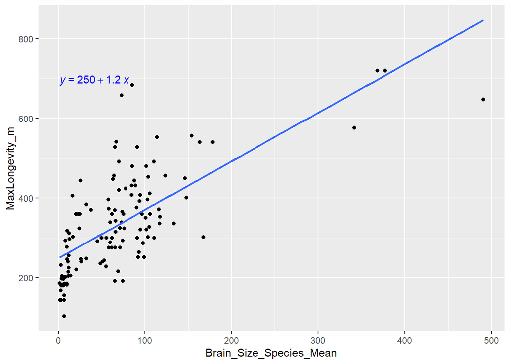

```r
ggplot(data = kc_df, aes(x = Brain_Size_Species_Mean, y = MaxLongevity_m))+
  geom_point()+
  geom_smooth(method = "lm", se = F, formula = y ~ x) + #add in line from lm regression, the model here should be identical to that used above
  stat_regline_equation(color = "blue") #added in by ggpubr, adds the regression equation automatically!
```

My interpretation of the slope is that for every increase of 1 in the brain size mean for the entire species, there is a 1.218 month increase in maximum longevity.

```r
mo_90ci <- confint(mo, level = 0.9) #calculate the 90% confidence interval for our slope
mo_90ci
```

```
##                                5 %      95 %
## (Intercept)             230.540738 267.36379
## Brain_Size_Species_Mean   1.035571   1.40041
```

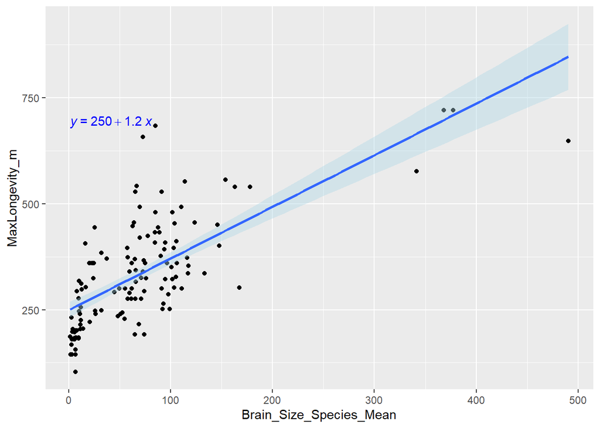

```r
ggplot(data = kc_df, aes(x = Brain_Size_Species_Mean, y = MaxLongevity_m))+
  geom_point()+
  geom_smooth(method = "lm", level = 0.9, fill = "lightblue", formula = y ~ x) + #geom_smooth includes a confidence interval by default, I just set the level to 90% to match the above
  stat_regline_equation(color = "blue")
```

```r
n800 <- data.frame(Brain_Size_Species_Mean = 800)
predict_800 <- predict(mo, newdata = n800, level = 0.90, interval = "predict")#[ ,"lwr"]
predict_800
```

```
##        fit      lwr      upr
## 1 1223.345 1021.805 1424.884
```

```r
predict2 <- as.data.frame(predict(mo, level = 0.90, interval = "predict"))
plus_predict <- cbind(kc_df, predict2)
```

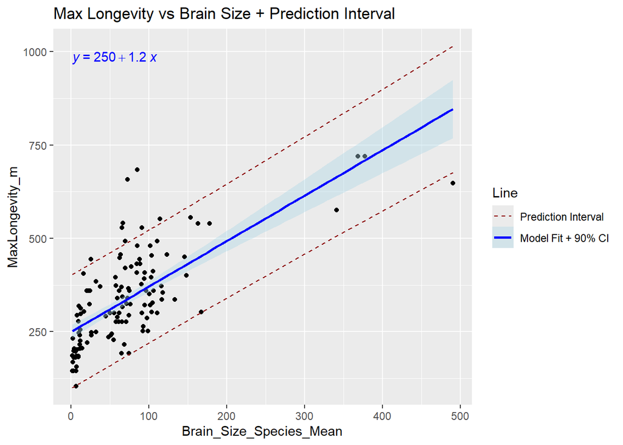

```r
ggplot(data = plus_predict, aes(x = Brain_Size_Species_Mean, y = MaxLongevity_m))+
  geom_point()+
  geom_smooth(aes(color = "Model Fit + 90% CI"), method = "lm", level = 0.9, fill = "lightblue", formula = y ~ x) +
  stat_regline_equation(color = "blue") +
  geom_line(aes( color = "Prediction Interval", y = lwr), linetype = "dashed")+
  geom_line(aes(color = "Prediction Interval", y = upr), linetype = "dashed")+
  ggtitle("Max Longevity vs Brain Size + Prediction Interval") +
  scale_color_manual(name='Line', # manual addition of legend
                     breaks=c("Prediction Interval", "Model Fit + 90% CI"),
                     values=c("Prediction Interval"="darkred", "Model Fit + 90% CI"="blue"))
```

## Do the same thing but with log transformed data!

```r
mo2 <- lm(log(MaxLongevity_m) ~ log(Brain_Size_Species_Mean), data = kc_df)
mo2
```

```
##
## Call:
## lm(formula = log(MaxLongevity_m) ~ log(Brain_Size_Species_Mean),
##     data = kc_df)
##
## Coefficients:
##                  (Intercept)  log(Brain_Size_Species_Mean)
##                       4.8790                        0.2341
```

```r
n800_log <- data.frame(Brain_Size_Species_Mean = 800)
predict_800log <- predict(mo2, newdata = n800, level = 0.90, interval = "predict")
predict_800log
```

```
##       fit      lwr      upr
## 1 6.44415 6.021424 6.866876
```

```r
predict3 <- as.data.frame(predict(mo2, level = 0.90, interval = "predict"))
plus_predict_log <- cbind(kc_df, predict3)
```

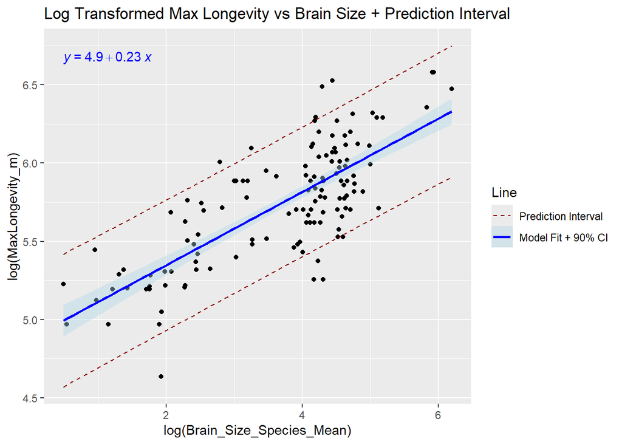

```r
ggplot(data = plus_predict_log, aes(x = log(Brain_Size_Species_Mean), y = log(MaxLongevity_m)))+
  geom_point()+
  geom_smooth(aes(color = "Model Fit + 90% CI"), method = "lm", level = 0.9, fill = "lightblue", formula = y ~ x) +
  stat_regline_equation(color = "blue") +
  geom_line(aes( color = "Prediction Interval", y = lwr), linetype = "dashed")+
  geom_line(aes(color = "Prediction Interval", y = upr), linetype = "dashed")+
  ggtitle("Log Transformed Max Longevity vs Brain Size + Prediction Interval") +
  scale_color_manual(name='Line',
                     breaks=c("Prediction Interval", "Model Fit + 90% CI"),
                     values=c("Prediction Interval"="darkred", "Model Fit + 90% CI"="blue"))
```

Overall I think I would trust the log-transformed model more, as visually the regression line seems to match the data a lot more closely and the prediction intervals seem to encompass more of the points. The log transformation seems to have reduced one of the major issues in the non-log transformed linear model where the majority of the data points were clustered around the lower end of the X axis with only a few outliers present at the other end, which made me question the validity of a linear model for the non-transformed data set. The log transformation handily reduces that problem and visually appears to be closer.